# Datasettøving 2: Tarmflora blant mødre og barn

Martine Sørgård Olsen og Karin Mollatt

2022-11-03

#### **Innledning**

Tarmfloraen til oss mennesker omhandler de bakteriene og mikroorganismene som tarmen vår består av. I denne rapporten skal vi studere tarmfloraen hos mødre og tilhørende barn gjennom data fra DNA/RNA-sekvensering av avføringsprøvene deres. Slik skal vi svare på spørsmålet: *Når får barn en tarmflora som ligner på den vi ser hos voksne?*

*Laster inn datasettet, og nødvendige pakker ved start.*

```r
library(tidyverse)
library(readxl)
library(pheatmap)
library(dichromat)
library(ggplot2)


data <- read_excel("mor_barn_tid_tarmflora.xlsx")
```

`data` inneholder 1124 rader og 1277 kolonner.

*For å bli bedre kjent med datarammen, ser vi på de seks første kolonnene.*

```r
# Her har vi fjernet #-tegnene som introduserer hver output ved hjelp
# av comment=NA blant chunk options, for en mer estetisk rapport.

data %>%
  select(1:6) %>% # Henter ut de 6 første kolonnene
  summary()
```

```
 MotherChildPairID MotherChild         Timepoint         Methanobrevibacter
 Min.   :19193     Length:1124        Length:1124        Min.   :  0.000
 1st Qu.:21851     Class :character   Class :character   1st Qu.:  0.000
 Median :22457     Mode  :character   Mode  :character   Median :  0.000
 Mean   :22318                                           Mean   :  4.532
 3rd Qu.:22927                                           3rd Qu.:  0.000
 Max.   :29193                                           Max.   :344.000
 Clostridiales       Dialister
 Min.   :  0.000   Min.   :  0.000
 1st Qu.:  0.000   1st Qu.:  0.000
 Median :  0.000   Median :  0.000
 Mean   :  1.597   Mean   :  2.771
 3rd Qu.:  0.000   3rd Qu.:  0.000
 Max.   :434.000   Max.   :784.000
```

Vi ser at:

- Hver observasjon består av en mor eller et barn.
- Kolonnene har ulike variabler:
  - `MotherChildPairID` er en ID som er unik for mor og tilhørende barn.
  - `MotherChild` kategoriserer om observasjonen er av mor eller barn.
  - `Timepoint` forteller når prøven er tatt. For mor er det tatt prøver under graviditeten og 3 måneder etter. For barna er det tatt prøver etter 10 dager, 3 måneder, ett år og to år.
  - De resterende kolonnene er ulike typer bakterier, som inneholder antallet av hver art.

*Videre skal vi definerte meningsfylte “factor levels”.*

```r
# Skriver ut de tre første verdiene av Timepoint og MotherChild
data %>%
  select(Timepoint, MotherChild) %>%
  slice_head(n=3)
```

```
# A tibble: 3 × 2
  Timepoint MotherChild
  <chr>     <chr>
1 Pregnancy mother
2 Pregnancy mother
3 Pregnancy mother
```

```r
data <- data %>%
  # Gjør om variablene Timepoint og MotherChild til typen factor,
  # og bruker levels til å angi den naturlige rekkefølgen
  mutate(Timepoint = factor(Timepoint,
                            levels = c("Pregnancy", "10days", "3months",
                                       "1year", "2years")),
         MotherChild = factor(MotherChild,
                              levels = c("mother", "child")))

# Skriver ut de tre første verdiene etter omgjøringen
data %>%
  select(Timepoint, MotherChild) %>%
  slice_head(n=3)
```

```
# A tibble: 3 × 2
  Timepoint MotherChild
  <fct>     <fct>
1 Pregnancy mother
2 Pregnancy mother
3 Pregnancy mother
```

*For å unngå store beregninger når vi prøver kode, lager vi et redusert datasett.*

```r
# Definerer et mindre datasett med kun de 6 første kolonnene for testing av kode
leke_data <- data %>%
  select(1:6) %>%
  group_by(MotherChild, Timepoint) %>%
  slice(1:3) %>%
  ungroup()
leke_data
```

```
# A tibble: 18 × 6
   MotherChildPairID MotherChild Timepoint Methanobrevibacter Clostrid…¹ Diali…²
               <dbl> <fct>       <fct>                  <dbl>      <dbl>   <dbl>
 1             23254 mother      Pregnancy                 49          0       0
 2             23474 mother      Pregnancy                  9          4       0
 3             22303 mother      Pregnancy                  0          0      85
 4             21407 mother      3months                  235          0       0
 5             23254 mother      3months                   59          0       0
 6             21831 mother      3months                    0          0       4
 7             22622 child       10days                     0          0       0
 8             22596 child       10days                     0          0       0
 9             22751 child       10days                     0          0       0
10             22255 child       3months                    0          0       0
11             22764 child       3months                    0          0       0
12             22085 child       3months                    0          0       0
13             22925 child       1year                      0          0       0
14             22529 child       1year                      0          0       0
15             22577 child       1year                      0          0       0
16             23150 child       2years                     1          0       0
17             22078 child       2years                     0          0       0
18             22858 child       2years                     0          1       0
# … with abbreviated variable names ¹Clostridiales, ²Dialister
```

### 3: La oss telle bakterier

#### **Hvor mange ulike taxa finnes i tarmfloraen til et individ?**

```r
# Definerer en dataramme som inneholder antall bakteriearter i hvert individ
leke_artsrikdom <- leke_data %>%
  gather(key = "art", value = "antall",
         -c(MotherChildPairID, MotherChild, Timepoint)) %>%
  group_by(MotherChildPairID, MotherChild, Timepoint) %>%
  summarise(arter = sum(antall > 0))
leke_artsrikdom
```

```
# A tibble: 18 × 4
# Groups:   MotherChildPairID, MotherChild [17]
   MotherChildPairID MotherChild Timepoint arter
               <dbl> <fct>       <fct>     <int>
 1             21407 mother      3months       1
 2             21831 mother      3months       1
 3             22078 child       2years        0
 4             22085 child       3months       0
 5             22255 child       3months       0
 6             22303 mother      Pregnancy     1
 7             22529 child       1year         0
 8             22577 child       1year         0
 9             22596 child       10days        0
10             22622 child       10days        0
11             22751 child       10days        0
12             22764 child       3months       0
13             22858 child       2years        1
14             22925 child       1year         0
15             23150 child       2years        1
16             23254 mother      Pregnancy     1
17             23254 mother      3months       1
18             23474 mother      Pregnancy     2
```

```r
artsrikdom <- data %>%
  gather(key = "art", value = "antall",
         -c(MotherChildPairID, MotherChild, Timepoint)) %>%
  group_by(MotherChildPairID, MotherChild, Timepoint) %>%
  summarise(arter = sum(antall > 0))
artsrikdom
```

```
# A tibble: 1,124 × 4
# Groups:   MotherChildPairID, MotherChild [526]
   MotherChildPairID MotherChild Timepoint arter
               <dbl> <fct>       <fct>     <int>
 1             19193 mother      Pregnancy   173
 2             19193 mother      3months     134
 3             20217 mother      3months     155
 4             20220 mother      Pregnancy   126
 5             20220 child       10days       20
 6             20220 child       3months      16
 7             20220 child       1year        55
 8             20220 child       2years       76
 9             20251 mother      Pregnancy   118
10             20251 mother      3months      93
# … with 1,114 more rows
# ℹ Use `print(n = ...)` to see more rows
```

#### **Hvordan endrer mangfoldet i tarmen seg over tid?**

```r
# Definerer en dataramme med gjennomsnittlig artsrikdom hos mor og barn
leke_gjsn_artsrikdom <- leke_artsrikdom %>%
  group_by(MotherChild, Timepoint) %>%
  summarise(gjsn_arter = mean(arter))
leke_gjsn_artsrikdom
```

```
# A tibble: 6 × 3
# Groups:   MotherChild [2]
  MotherChild Timepoint gjsn_arter
  <fct>       <fct>          <dbl>
1 mother      Pregnancy      1.33
2 mother      3months        1
3 child       10days         0
4 child       3months        0
5 child       1year          0
6 child       2years         0.667
```

```r
gjsn_artsrikdom <- artsrikdom %>%
  group_by(MotherChild, Timepoint) %>%
  summarise(gjsn_arter = mean(arter))
gjsn_artsrikdom
```

```
# A tibble: 6 × 3
# Groups:   MotherChild [2]
  MotherChild Timepoint gjsn_arter
  <fct>       <fct>          <dbl>
1 mother      Pregnancy      130.
2 mother      3months        131.
3 child       10days          22.4
4 child       3months         26.4
5 child       1year           58.6
6 child       2years          87.6
```

Man kan se på outputen at gjennomsnittlig antall bakteriearter for barn øker jevnt med alderen, mens antallet for mødre holder seg stabilt under og etter graviditet.

#### **Fordeling (boksplott)**

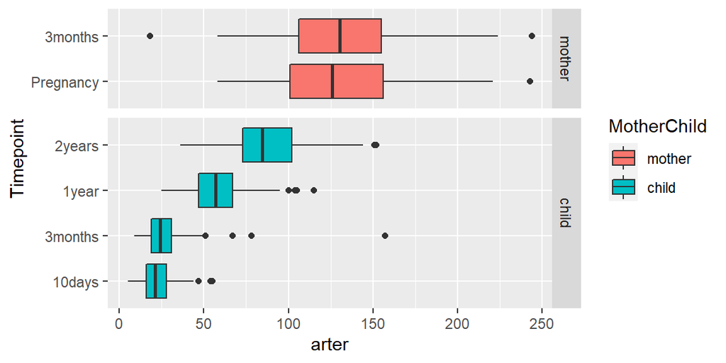

```r
# Plotter antall taxa i hver observasjonsgruppe i et boxplot
artsrikdom %>%
  group_by(MotherChild, Timepoint) %>%
  ggplot(mapping = aes(x = Timepoint, y = arter, fill = MotherChild)) +
  geom_boxplot() +
  facet_grid(facets = vars(MotherChild), scales = "free", space = "free") +
  coord_flip()
```

Utifra boxplottet kan vi tydelig se at tidligere antatt mønster ser ut til å stemme. Gjennomsnittlig antall bakteriearter øker med alderen før det så ser ut til å stabilisere seg. Kurven kan minne om en eksponentiell økning.

#### **Hvilke taxa er mest vanlige?**

```r
# Grupperer data etter mor/barn og tidspunkt, og regner ut hvor stor andel av observasjonene som inneholder de ulike bakterieartene.
forekomst <- data %>%
  group_by(MotherChild, Timepoint) %>%
  summarise_at(vars(-MotherChildPairID), ~mean(. > 0))
forekomst
```

```
# A tibble: 6 × 1,276
# Groups:   MotherChild [2]
  MotherChild Timepoint Methan…¹ Clost…² Diali…³ Rumin…⁴ Rumin…⁵ Faeca…⁶ Lachn…⁷
  <fct>       <fct>        <dbl>   <dbl>   <dbl>   <dbl>   <dbl>   <dbl>   <dbl>
1 mother      Pregnancy  0.317   0.126    0.150  0.503    0.760   0.964   0.114
2 mother      3months    0.365   0.1      0.18   0.585    0.835   0.925   0.12
3 child       10days     0.0112  0.00562  0.0281 0.0112   0.0674  0.0618  0
4 child       3months    0.00518 0        0.0725 0.00518  0.0466  0.0363  0
5 child       1year      0.0139  0        0.116  0.0833   0.0694  0.671   0.0602
6 child       2years     0.0353  0.0471   0.147  0.247    0.282   0.929   0.135
# … with 1,267 more variables: Mollicutes <dbl>, Bacteroides <dbl>,
#   Dialister.1 <dbl>, Bacteroides.1 <dbl>, Ruminococcaceae.1 <dbl>,
#   Christensenellaceae <dbl>, Bacteroides.2 <dbl>, Bifidobacterium <dbl>,
#   Mollicutes.1 <dbl>, Bacteroides.3 <dbl>, Clostridiales.1 <dbl>,
#   Erysipelotrichaceae <dbl>, Mollicutes.2 <dbl>, Ruminococcaceae.2 <dbl>,
#   Eubacterium <dbl>, Blautia <dbl>, Ruminococcaceae.3 <dbl>,
#   Rikenellaceae <dbl>, Blautia.1 <dbl>, Clostridiales.2 <dbl>, …
# ℹ Use `colnames()` to see all variable names
```

`forekomst` inneholder 6 rader, som representerer hver observasjonstidspunkt for mor og barn. Det vil si under graviditet og 3 måneder etter fødsel for mødrene, og 10 dager, 3 måneder, ett år og to år for barna.

#### **Plotting**

```r
# Omstrukturer datarammen slik at artene samles i en kolonne med tilhørende verdier i en egen kolonnne.
forekomst.lang <- forekomst %>%
  gather(key = "art", value = "andel_individer",
         -c(MotherChild, Timepoint))
forekomst.lang
```

```
# A tibble: 7,644 × 4
# Groups:   MotherChild [2]
   MotherChild Timepoint art                andel_individer
   <fct>       <fct>     <chr>                        <dbl>
 1 mother      Pregnancy Methanobrevibacter         0.317
 2 mother      3months   Methanobrevibacter         0.365
 3 child       10days    Methanobrevibacter         0.0112
 4 child       3months   Methanobrevibacter         0.00518
 5 child       1year     Methanobrevibacter         0.0139
 6 child       2years    Methanobrevibacter         0.0353
 7 mother      Pregnancy Clostridiales              0.126
 8 mother      3months   Clostridiales              0.1
 9 child       10days    Clostridiales              0.00562
10 child       3months   Clostridiales              0
# … with 7,634 more rows
# ℹ Use `print(n = ...)` to see more rows
```

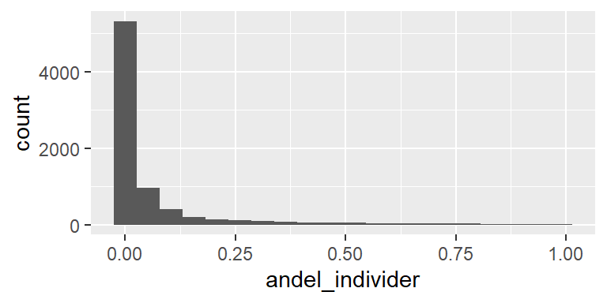

```r
# Lagrer histogram plott av datarammen til en variabel for senere bruk, og viser så plottet
phist <- forekomst.lang %>%
  ggplot(mapping = aes(x = andel_individer)) +
  geom_histogram(bins = 20)
phist
```

#### **En nærmere titt på de vanligste artene**

```r
# Finner bakteriearter som forekommer over 90% av individene i datasettet, og sorterer etter andel individer
taxa_90 <- forekomst.lang %>%
  filter(andel_individer >= 0.90) %>%
  arrange(andel_individer)
taxa_90
```

```
# A tibble: 15 × 4
# Groups:   MotherChild [2]
   MotherChild Timepoint art                andel_individer
   <fct>       <fct>     <chr>                        <dbl>
 1 mother      3months   Faecalibacterium.1           0.9
 2 child       2years    Coprococcus.3                0.9
 3 mother      Pregnancy Ruminococcaceae.3            0.904
 4 child       1year     Bifidobacterium              0.912
 5 mother      Pregnancy Bifidobacterium              0.922
 6 mother      3months   Faecalibacterium             0.925
 7 child       2years    Faecalibacterium             0.929
 8 child       10days    Streptococcus                0.933
 9 child       3months   Bifidobacterium              0.938
10 mother      Pregnancy Ruminococcaceae.2            0.940
11 mother      3months   Lachnospiraceae.1            0.955
12 mother      Pregnancy Faecalibacterium             0.964
13 mother      Pregnancy Faecalibacterium.1           0.970
14 child       10days    Staphylococcus               0.978
15 mother      Pregnancy Lachnospiraceae.1            0.988
```

[*Faecalibacterium*](https://en.wikipedia.org/wiki/Faecalibacterium%3EFaecalibacterium) er en stavformet, tallrik bakterieart som utgjør mer enn 5% av bakteriene i tarmen. Den er også en viktig [kommensal](https://snl.no/kommensalisme) bakterie som betyr at den tar nytte av interaksjonen med en annen art uten at den andre bakteriearten blir påvirket.

[*Streptococcus*](https://en.wikipedia.org/wiki/Streptococcus), bedre kjent som streptokokk på norsk, får nok de fleste til å tenke på halsbetennelse. I midlertid er mange streptokokkarter ikke farlige, og de utgjør en del av den kommensale menneskelige mikrobiotaen i munn, øvre luftveier, hud og tarm.

[*Lachnospiraceae*](https://en.wikipedia.org/wiki/Lachnospiraceae) er også en av bakteriene som er blant de mest tallrike taxaene i den menneskelige tarmfloraen. De fermenterer forskjellige plantepolysakkarider til kortkjedede fettsyrer (butyrat, acetat) og alkoholer (etanol).

#### **Plotting pr tid og mor/barn**

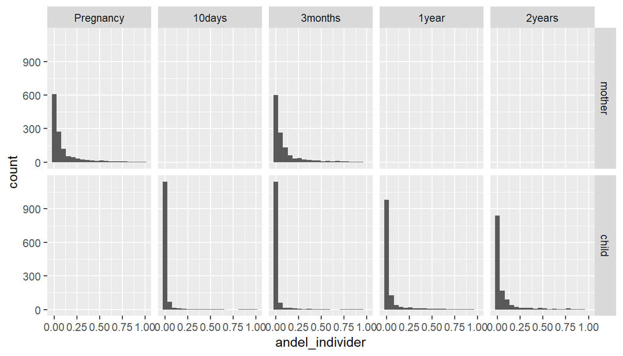

```r
# Bygger på plottet som er definert tidligere, for å lage et histogram for hver observasjonsgruppe
plott_tid_mor_barn <- phist +
  facet_grid(rows = vars(MotherChild), cols = vars(Timepoint))
plott_tid_mor_barn
```

De høye stolpene til venstre i hvert plott kommer av at det finnes mange bakteriearter som kun en liten andel individer innehar.

Forekomst-mønsteret endrer seg ved at histogrammet blir jevnere fordelt når alderen øker, og vil til slutt nærme seg en negativ eksponentiell kurve. Biologisk betyr dette at det blir færre bakteriearter som få individer innehar. Det kan ha noe med at i løpet av de 10 første dagene vil et barn mest sannsynlig kun oppholde seg med mor og far. Der vil de bli passet godt på og kun bli utsatt for en begrenset mengde bakterier. Etter ett år eller to vil barnet ha kommet i kontakt med mange flere bakteriearter, som gjør at kurven vil flate seg ut.

Noen fasetter er helt uten observasjoner fordi at `mother` kun er målt ved svangerskap og tre måneder etter fødsel, mens `child` er målt ved alle tidspunktene med unntak av ved svangerskap.

#### **Bakterier som ikke forekommer i datasettet**

```r
# Velger ut bakteriearter som kun har nullverdier
nullbakt <- data %>%
  select(where(function(x) is.numeric(x) && all(x == 0))) %>%
  names()
nullbakt
```

```
[1] "Mycoplasma"          "Butyrivibrio"        "Helicobacter"
[4] "Bifidobacterium.11"  "Ruminococcaceae.238" "Lactobacillus.13"
```

```r
# Fjerner bakterier som ikke forekommer i noen observasjoner
data <- data %>%
  select(-!!nullbakt)
# Printer dimensjonen av datarammen
dim(data)
```

```
[1] 1124 1271
```

Dimensjonen på `data` er nå 1124x1271 i motsetning til den tidligere dimensjonen 1124x1277. Det er fordi vi har fjernet de 6 taxa (oppført som kolonner) som ikke forekommer i noen observasjoner.

### 4: Kvantitative data - fra telling til multivariat analyse

#### **Normalisering**

```r
# Fjerner de 3 første kolonnene som ikke inneholder tallverdier
data.norm.tallverdier <- data[,-(1:3)]

# Normaliserer verdiene i datarammen
clr <- log2(data.norm.tallverdier + 1) -
  apply(log2(data.norm.tallverdier + 1), 1, mean)

# Legger til de 3 første kolonnene som identifiserer prøvene
data.norm <- bind_cols(data[,1:3], as_tibble(clr))
data.norm
```

```
# A tibble: 1,124 × 1,271
   MotherChild…¹ Mothe…² Timep…³ Metha…⁴ Clost…⁵ Diali…⁶ Rumin…⁷ Rumin…⁸ Faeca…⁹
           <dbl> <fct>   <fct>     <dbl>   <dbl>   <dbl>   <dbl>   <dbl>   <dbl>
 1         23254 mother  Pregna…   5.19   -0.454  -0.454   4.90    4.79    4.45
 2         23474 mother  Pregna…   3.07    2.07   -0.255   3.74   -0.255   5.89
 3         22303 mother  Pregna…  -0.349  -0.349   6.08    1.97    1.24    6.42
 4         22623 mother  Pregna…   1.62   -0.379  -0.379   1.21    4.62    6.49
 5         21858 mother  Pregna…  -0.279  -0.279  -0.279  -0.279   3.63    4.18
 6         21514 mother  Pregna…   1.28   -0.306  -0.306   0.694   4.60    5.72
 7         22640 mother  Pregna…   1.29   -0.295  -0.295  -0.295  -0.295   5.51
 8         22419 mother  Pregna…  -0.317  -0.317  -0.317   2.85   -0.317   0.683
 9         23107 mother  Pregna…  -0.267  -0.267  -0.267   3.54    1.73    5.57
10         23124 mother  Pregna…  -0.256  -0.256  -0.256   0.744   2.07    6.12
# … with 1,114 more rows, 1,262 more variables: Lachnospiraceae <dbl>,
#   Mollicutes <dbl>, Bacteroides <dbl>, Dialister.1 <dbl>,
#   Bacteroides.1 <dbl>, Ruminococcaceae.1 <dbl>, Christensenellaceae <dbl>,
#   Bacteroides.2 <dbl>, Bifidobacterium <dbl>, Mollicutes.1 <dbl>,
#   Bacteroides.3 <dbl>, Clostridiales.1 <dbl>, Erysipelotrichaceae <dbl>,
#   Mollicutes.2 <dbl>, Ruminococcaceae.2 <dbl>, Eubacterium <dbl>,
#   Blautia <dbl>, Ruminococcaceae.3 <dbl>, Rikenellaceae <dbl>, …
# ℹ Use `print(n = ...)` to see more rows, and `colnames()` to see all variable names
```

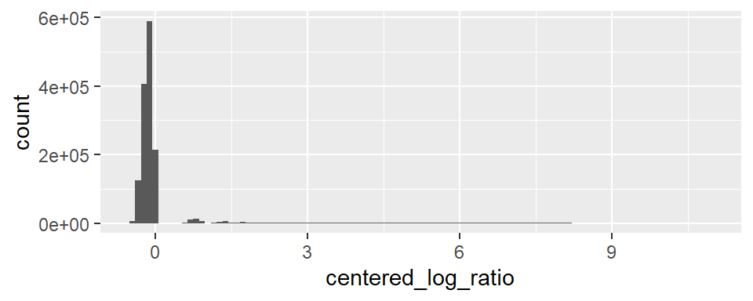

```r
# Histogram
data.norm %>%
  gather(key = "art", value = "centered_log_ratio",
         -c(MotherChildPairID, MotherChild, Timepoint)) %>%
  ggplot(mapping = aes(x = centered_log_ratio)) +
  geom_histogram(bins = 100)
```

Disse dataene er kvantitative og måler “antall bakterier” fra hvert taxon. Likevel kan vi ikke sammenlikne de fordi det er ulikt antall reads fra hver prøve. For å kunne gjøre dette transformerer vi dataene gjennom 2 operasjoner:

1. Først gjennomfører vi en log2-transformasjon slik at alle verdiene blir log2-verdier som er lettere å tolke i hodet enn naturlige logaritmer. Denne transformasjonen vektlegger *relativ* variasjon der en økning med én log2-enhet vil være en dobling av den opprinnelige verdien. Siden verdiene våre ikke har et absolutt nullpunkt legger vi til 1 for å unngå at nullverdiene blir ubrukelige (log2(x)= - ∞).
2. Videre trekker vi fra gjennomsnittet av log2-verdien til alle verdiene i den raden/observasjonen. Dette kalles *sentrering* av dataene, og det gjør at gjennomsnittet til hver rad etter normalisering blir lik null.

Vi ser på histogrammet at transformeringen støtter antakelsen om at det er mange bakteriearter som få barn innehar. Samtidig ser vi også at histogrammet har stolper høyere opp på skalaen, da dette representerer bakteriene som mange personer besitter.

#### **Prinsipalkomponentanalyse (PCA)**

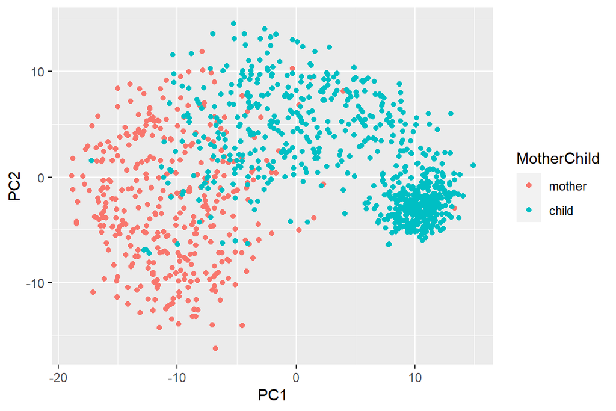

```r
# Kjører en Principal Component Analysis
pca.res <- prcomp(data.norm[,-(1:3)])
data.pca <- bind_cols(data.norm[,1:3], as_tibble(pca.res$x))

# Plotter tarmprøvene
data.pca %>%
  ggplot(mapping = aes(x = PC1, y = PC2, color = MotherChild)) +
  geom_point()
```

På plottet kan man se at punktene til mor og barn overlapper noe, og dette kan tyde på en korrelasjon mellom disse datapunktene.

Det finnes to hypoteser om når barn får en “voksen” tarmflora: under/rett etter fødselen eller betydelig senere.

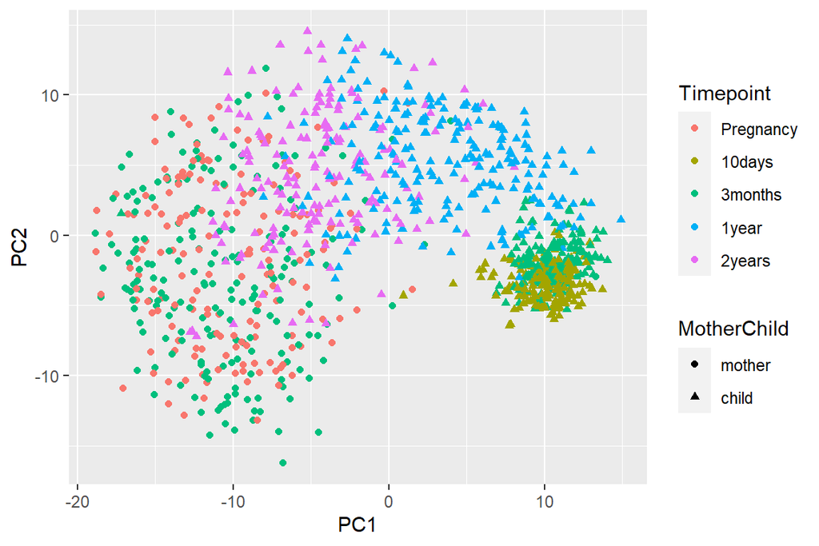

```r
data.pca %>%
  ggplot(mapping = aes(x = PC1, y = PC2, color = Timepoint,
                       shape = MotherChild)) +
  geom_point()
```

**Når får barn en tarmflora som ligner på den vi ser hos voksne?**

På plottet ser man at der punktene fra barn (▲) møter punktene fra mor (●) er når trekantene er rosa, altså tilsvarende en alder på 2 år. Det vil si at barn får en tarmflora som ligner på den vi ser hos voksne rundt 2 års alder.

```r
loadings <- as_tibble(pca.res$rotation, rownames = "art")

# Topp 10 taxa som bidrar mest til PC1 (usortert)
loadings %>%
  top_n(10, abs(PC1)) %>%
  select(1:2)
```

```
# A tibble: 10 × 2
   art                   PC1
   <chr>               <dbl>
 1 Ruminococcaceae    -0.152
 2 Faecalibacterium   -0.194
 3 Dialister.1        -0.169
 4 Ruminococcaceae.2  -0.171
 5 Ruminococcaceae.3  -0.190
 6 Lachnospiraceae.1  -0.231
 7 Ruminococcus.1     -0.148
 8 Faecalibacterium.1 -0.202
 9 Bacteroides.8      -0.156
10 Bifidobacterium.8   0.147
```

*Lachnospiraceae.1* og *Faecalibacterium* er skrevet om tidligere i rapporten.

[*Bifidobacterium.8*](https://bramat.no/verktoy/436-bifidobacterium) er en av de viktigste slektene av bakterier som utgjør mikrobiotaen i mage-tarmkanalen hos pattedyr<sup>[1](https://en.wikipedia.org/wiki/Bifidobacterium)</sup>. Den produserer melkesyre ut av sukker, da det er en melkesyrebakterie som også kan brukes som probiotika i f.eks. melkesyrnede produkter.

[*Ruminococcus.1*](https://pubmed.ncbi.nlm.nih.gov/29492877/) er en bakterieslekt under klassen Clostridia, og en eller flere arter av denne finnes i betydelig antall i menneskets tarmflora<sup>[2](https://en.wikipedia.org/wiki/Ruminococcus)</sup>. Bakteriearten bryter ned og omdanner polysakkarider til næringsstoffer.

[*Bacteroides.8*](https://sml.snl.no/Bacteroides) er en slekt som utgjør en stor del av tarmfloraen og kan forårsake ulike infeksjoner.

```r
# Topp 10 taxa som bidrar mest til PC2 (usortert)
loadings %>%
  top_n(10, abs(PC2)) %>%
  select(c(1,3))
```

```
# A tibble: 10 × 2
   art                      PC2
   <chr>                  <dbl>
 1 Ruminococcaceae       -0.192
 2 Bifidobacterium        0.134
 3 Blautia                0.264
 4 Clostridiaceae.1       0.152
 5 Coprococcus.3          0.261
 6 Clostridiales.14       0.152
 7 Bifidobacterium.4      0.153
 8 Staphylococcus        -0.131
 9 Granulicatella         0.182
10 Erysipelotrichaceae.7  0.215
```

Det taxonet som har størst bidrag til PC1, og som derfor er viktigst, er *Lachnospiraceae.1*. For PC2 er det viktigste taxonet *Blautia*. Dersom du plotter disse to mot hverandre, vil du få dette plottet.

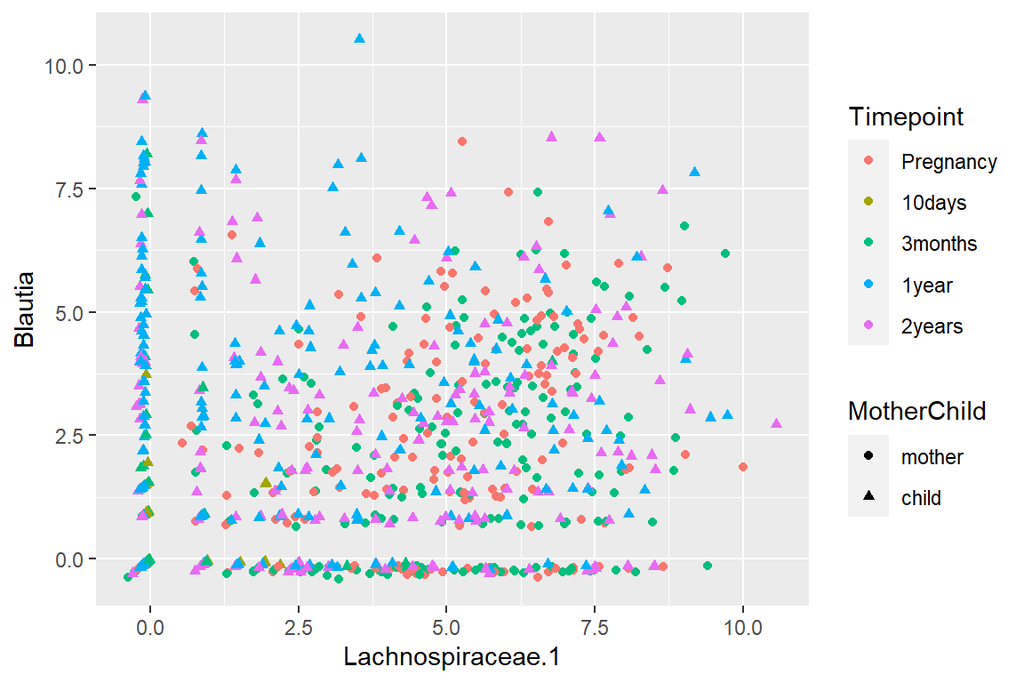

```r
# Plotter viktigste taxon i PC1 og i PC2 mot hverandre, og kategoriserer farge etter tidspunkt og form etter mor/barn.
data.norm %>%
  ggplot(mapping = aes(x = Lachnospiraceae.1, y = Blautia,
                       color = Timepoint, shape = MotherChild)) +
  geom_point()
```

```r
# Skriver ut "varians forklart" for de 10 første PCene
eigs <- pca.res$sdev^2
var.forklart <- eigs / sum(eigs)
var.forklart[1:10]
```

```
 [1] 0.15260383 0.05045699 0.03315248 0.02448756 0.02146327 0.01671577
 [7] 0.01584048 0.01506326 0.01371406 0.01312990
```

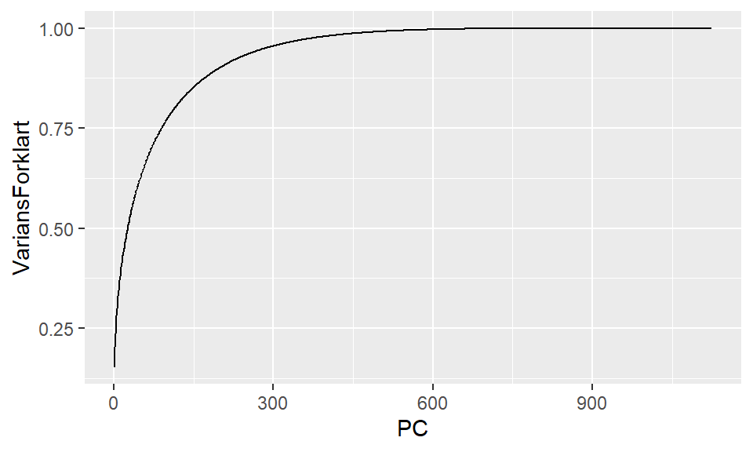

```r
# Plotter kumulativ fordeling av varians forklart av alle PCene
ggplot(data.frame(PC = 1:length(var.forklart),
                  VariansForklart = cumsum(var.forklart)),
       aes(x = PC, y = VariansForklart)) +
  geom_line()
```

I en prinsipalkomponentanalyse er målet at PCene skal forklare så mye varians som mulig. Det vil si at PC1 forklarer absolutt mest varians, PC2 nest mest osv. På plottet som viser varians forklart ser vi at de to første PCene kun forklarer rundt 20% av variansen i dataene. Dette betyr at det finnes flere PCer som forklarer en betydelig del av variansen. Likevel gir det oss et klart bilde av hvordan tarmfloraen hos mor og barn utvikles over tid, fordi en økning på 20% på kun to PCer tyder på en eksponentiell økning.

### 4.3: Heatmap

```r
data.norm.m <- data.norm[,-(1:3)] %>% as.matrix()
rad_annotering <- data.norm[,2:3] %>% as.data.frame()

rownames(data.norm.m) <- 1:nrow(data.norm.m)
rownames(rad_annotering) <- 1:nrow(rad_annotering)

# De tre første radene og kolonnene
data.norm.m[1:3,1:3]
```

```
  Methanobrevibacter Clostridiales  Dialister
1          5.1895029    -0.4543533 -0.4543533
2          3.0666002     2.0666002 -0.2553279
3         -0.3492213    -0.3492213  6.0770435
```

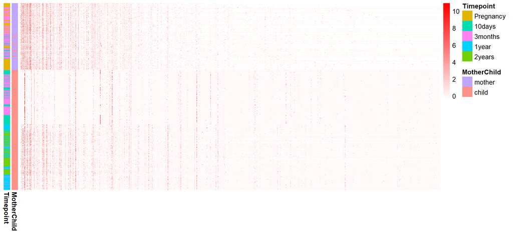

```r
# Heatmap
pheatmap(data.norm.m,
         color = colorRampPalette(c("white","red"))(50),
         border_color = NA,
         cluster_rows = FALSE,
         cluster_cols = FALSE,
         show_rownames = FALSE,
         show_colnames = FALSE,
         annotation_row = rad_annotering,
         display_numbers = FALSE)
```

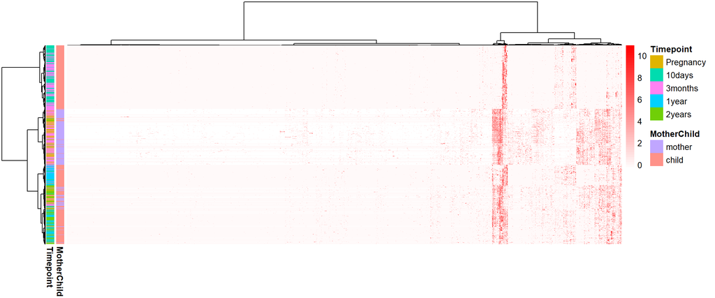

```r
# Heatmap der dataen er omstokket
pheatmap(data.norm.m,
         color = colorRampPalette(c("white","red"))(50),
         border_color = NA,
         cluster_rows = TRUE, cluster_cols = TRUE,
         clustering_method = "ward.D",
         show_rownames = FALSE, show_colnames = FALSE,
         annotation_row = rad_annotering,
         display_numbers = FALSE)
```

Heatmapet viser en fordeling der bakterieartene blir delt inn i to hovedgrupper, der hovedgruppe nr.2 (til høyre) forekommer hyppigst. Videre blir hovedgruppe 2 delt inn i to undergrupper, der den første undergruppen (til venstre) er den som forekommer absolutt mest blant alle bakterieartene.